# R Notebook

# Project Details

## The Book

Methods in Biostatistics with R Ciprian Crainiceanu, Brian Caffo, John Muschelli

- Intro Video: https://www.youtube.com/watch?v=MG1lZhixbS4
- Site: https://leanpub.com/biostatmethods

## The Data

From the Book

- https://github.com/muschellij2/biostatmethods

# Chapter 1. Introduction

“….We provide a modern look at introductory biostatistical concepts and associated computational tools, reflecting the latest developments in computation and vi- sualization using the R language environment (R Core Team 2016). The idea is to offer a complete, online, live book that evolves with the newest developments and is continuously enriched by additional concepts…”

1.1 Biostatistics

“….Biostatistics is the theory and methodology for the acquisition and use of quantitative evidence in biomedical research. Biostatisticians develop innovative designs and analytic methods targeted at increasing available information, improving the relevance and validity of statistical analyses, making best use of available information and communicating relevant uncertainties….”

“….Biostatistics is a challenging subject to master if one is interested in understanding both the underlying concepts and their appropriate implementation. ….Biostatistics can be viewed as a powerful and practical philosophy of science, in which the scientific hypothesis, the experiment, the data, the model, and the associated inference form the basis of scientific progress. ….Biostatistics is hard because it is focused on solving difficult problems using simple approaches and simplicity is difficult to achieve in complex scenarios. ….Biostatistics is not hard in the usual sense that it requires either deep mathematical concepts or committing large books to memory….”

“….The difficulty of biostatistics rests in the different philosophy, the different way of thinking, and the different set of skills required to process human communication of scientific problems and their translation into well-defined problems that can be solved with data. Once a scientific promlem is defined, the biostatistics philosophy is to try to solve it using the simplest possible approaches that are not too simplistic. Thus, parsimony and inductive reasoning are fundamental concepts in biostatistics….”

“….biostatistics starts with the current accepted state of knowledge (the collection of null hypotheses) and uses data to inductively refute or reinforce parts of the knowledge or generate new potential knowledge (new null hypotheses). In the biostatistical philosophy there is no truth, just the state of current knowledge….”

“….Biostatistics requires: (1) a tight coupling of the biostatistical methods with ethical and scientific goals of research; (2) an emphasis on the scientific interpretation of statistical evidence to impact policy; and (3) a detailed acknowledgment of assumptions and a comprehensive evaluation of the robustness of conclusions to these assumptions….”

# Chapter 2. Introduction to R

## 2.4 Objects In R

“….Almost everything is an “object” or “variable.”….most things are relevant only with respect to a data set…."

## 2.5 Assignment

“….There is also a “forward assignment” operator that exists, but this is rarely used and we do not recommend using it…." Oh no.

## 2.6 Data types In R

“….The three most fundamental: numeric (numbers), character (strings or “words”), and logicals (TRUE or FALSE).

“….One additional data type: factors. Factors are categorical data types. The categories of a factor are called the “levels” of that factor. The levels of factors usually contain human-readable levels (e.g., “Male” and “Female”). Factors become increasingly useful when we fit models, as one can define the baseline category by the levels of the factor, which affects the interpretation of coefficients. Some refer to vectors of length 1 as a “scalar”. In other languages, there is a distinction between scalars and vectors, but not in R. So you can think of a vector as a 1-dimensional object that can have anywhere from 0 to a large number of elements…."

## 2.7.1 More than one number: vectors In R

“….Anything having one dimension is generally referred to as a “vector”. A vector has a specified length. Technically, a vector may have length 0, which means nothing is in it. But usually vectors have one or multiple objects in them. Those objects all must have the same data type (e.g., all numbers or all characters or all logicals)…."

## 2.7.3 Sequences

```r
1:5
```

```
## [1] 1 2 3 4 5
```

```r
-5:1
```

```
## [1] -5 -4 -3 -2 -1  0  1
```

```r
-(5:1)
```

```
## [1] -5 -4 -3 -2 -1
```

```r
seq(1,5)
```

```
## [1] 1 2 3 4 5
```

```r
seq(1,7, by = 0.4)
```

```
##  [1] 1.0 1.4 1.8 2.2 2.6 3.0 3.4 3.8 4.2 4.6 5.0 5.4 5.8 6.2 6.6 7.0
```

```r
seq(by = 0.4, to = 7, from = 1)
```

```
##  [1] 1.0 1.4 1.8 2.2 2.6 3.0 3.4 3.8 4.2 4.6 5.0 5.4 5.8 6.2 6.6 7.0
```

## 2.7.4 Operations on numeric vectors

```r
x_length_2 = c(1, 2)
x_length_2 * 3
```

```
## [1] 3 6
```

```r
sqrt(x_length_2)
```

```
## [1] 1.000000 1.414214
```

## 2.7.5 Some standard operations on vectors

```r
x_length_3 = c(10, 20, 30)
length(x_length_3)
```

```
## [1] 3
```

```r
x = c(2, 1, 1, 4)
sort(unique(x))
```

```
## [1] 1 2 4
```

```r
sample(x)
```

```
## [1] 1 4 2 1
```

```r
sample(x, size = 2)
```

```
## [1] 2 1
```

```r
# sample(x, size = 10) will error
sample(x, size = 10, replace = TRUE)
```

```
##  [1] 2 1 2 4 1 1 2 1 1 1
```

## 2.7.7 Data type coercion

“….Vectors can only have one data type in them….”

“….Logicals can be coerced to numerics (0 and 1 values) and coerced to characters (”TRUE" and “FALSE”, note the quotes). Numerics can be coerced into characters (5.6 changes to “5.6”)…."

You can determine the data type of an object with the typeof() function:

```r
typeof(c(5.2, TRUE, FALSE))
```

```
## [1] "double"
```

## 2.7.8 More than one dimension: Matrices

“….A matrix is like a vector, but it has two dimensions, rows and columns. Like vectors, matrices can contain only one data type….” So I imagine a vector is just ‘A row’ and a matrix is ‘A row and a column’, or something like that

```r
matrix(1)
```

```
##      [,1]
## [1,]    1
```

```r
matrix(1:6, nrow = 2, ncol = 3)
```

```
##      [,1] [,2] [,3]
## [1,]    1    3    5
## [2,]    2    4    6
```

```r
matrix(1:6, nrow = 2, ncol = 3, byrow = TRUE) # filled by row
```

```
##      [,1] [,2] [,3]
## [1,]    1    2    3
## [2,]    4    5    6
```

## 2.7.9 More than one dimension: data.frames

“….A data.frame is like a matrix in that it has rows and columns. A data.frame can have columns of different data types….”

….Note, a default on the data.frame() function is stringsAsFactors = TRUE, which indicates that all strings should be converted to factors. Many times, you want to clean these columns and then convert them to factors directly. So we will set that option to FALSE…."

```r
df = data.frame(age = c(25, 30, 32, 42),
                handed = c("left", "right", "ambidextrous", "left"),
                stringsAsFactors = FALSE)
```

## 2.7.10 Dimensions of an object

There are functions that get attributes about a matrix/data.frame that are useful for analysis.

The dim function returns the dimensions (rows and columns, respectively) of a data set:

```r
df = data.frame(age = c(25, 30, 32, 42),
                handed = c("left", "right", "ambidextrous", "left"),
                stringsAsFactors = FALSE)
dim(df)
```

```
## [1] 4 2
```

Number of rows or columns

```r
df = data.frame(age = c(25, 30, 32, 42),
                handed = c("left", "right", "ambidextrous", "left"),
                stringsAsFactors = FALSE)
nrow(df)
```

```
## [1] 4
```

```r
ncol(df)
```

```
## [1] 2
```

## 2.8 Logical operations

“….Perform some logical tests that return logical data. greater/less than (>, <) greater/less than or equal to (>=, <=) equal to (== “double equals”) and not equal to (!=) These are called “relational operators” or “comparison operators”

There are also the standard “logical operators”: not/negate (!), AND (&), and OR (|)…."

```r
x = c(1, 3, 4, 5)
x < 4
```

```
## [1]  TRUE  TRUE FALSE FALSE
```

```r
x > 3
```

```
## [1] FALSE FALSE  TRUE  TRUE
```

```r
x >= 3
```

```
## [1] FALSE  TRUE  TRUE  TRUE
```

```r
x == 3
```

```
## [1] FALSE  TRUE FALSE FALSE
```

```r
x != 3
```

```
## [1]  TRUE FALSE  TRUE  TRUE
```

```r
x = c(1, 3, 4, 5)
x > 3 | x == 1
```

```
## [1]  TRUE FALSE  TRUE  TRUE
```

```r
!(x > 3 | x == 1) # negates the statement - turns TRUE to FALSE [1] FALSE TRUE FALSE FALSE
```

```
## [1] FALSE  TRUE FALSE FALSE
```

```r
x != 3 & x != 5
```

```
## [1]  TRUE FALSE  TRUE FALSE
```

```r
x == 3 | x == 4
```

```
## [1] FALSE  TRUE  TRUE FALSE
```

## 2.8.1 The %in% Operator

“….Many times, we want to keep or exclude based on a number of values….”

```r
x = c(1, 3, 4, 5)
x %in% c(3,4)
```

```
## [1] FALSE  TRUE  TRUE FALSE
```

This feels like an “is in?” or may even an “is?” in that it asks: “are any of these values in the vector?”.

## 2.9 Subsetting 2.9.1 Subsetting vectors

```r
x = c(1, 3, 4, 5)
x[4]
```

```
## [1] 5
```

```r
x > 2
```

```
## [1] FALSE  TRUE  TRUE  TRUE
```

```r
x[ x > 2 ]
```

```
## [1] 3 4 5
```

## 2.9.2 Subsetting matrices

“….the syntax is [row subset, column subset]….”

```r
mat = matrix(1:6, nrow = 2)
mat[1:2, 1]
```

```
## [1] 1 2
```

```r
mat[1, 1:2]
```

```
## [1] 1 3
```

```r
mat[1, c(FALSE, TRUE, FALSE)]
```

```
## [1] 3
```

```r
mat[, c(FALSE, 3, TRUE)]
```

```
##      [,1] [,2]
## [1,]    5    1
## [2,]    6    2
```

```r
mat[1:2, ]
```

```
##      [,1] [,2] [,3]
## [1,]    1    3    5
## [2,]    2    4    6
```

```r
mat[, 2:3]
```

```
##      [,1] [,2]
## [1,]    3    5
## [2,]    4    6
```

```r
mat[, c(FALSE, TRUE, FALSE)]
```

```
## [1] 3 4
```

“….You can ensure that the result is a matrix, even if the result is one-dimensional using the drop = FALSE argument….”

```r
mat[,1, drop = FALSE]
```

```
##      [,1]
## [1,]    1
## [2,]    2
```

## 2.12.1 Tibbles

Implemented in the tibble package. It is like a data.frame

- Never coerces inputs (i.e. strings stay as strings!).
- Never adds row.names.
- Never changes column names.
- Only recycles length 1 inputs. (no wraparound)
- Automatically adds column names.

```r
tbl = tibble::as_tibble(df)
```

## 2.13 Problems

### Problem 1. Consider the vector: num <- c(“1.5”, “2”, “8.4”)

1. Convert num into a numeric vector using as.numeric

```r
num <- c("1.5", "2", "8.4")
as.numeric(num)
```

```
## [1] 1.5 2.0 8.4
```

2. Convert num into a factor using factor, calling it num_fac.

```r
num <- c("1.5", "2", "8.4")
num_fac <- factor(num)
```

3. Convert num_fac into a numeric using as.numeric.

```r
as.numeric(num_fac)
```

```
## [1] 1 2 3
```

4. Convert num_fac into a numeric using as.numeric(as.character())

```r
as.numeric(as.character(num_fac))
```

```
## [1] 1.5 2.0 8.4
```

### Problem 2. Consider the vector: num <- c(0, 1, 1, 0)

1. Append TRUE to the num vector using c.

```r
num <- c(0, 1, 1, 0)
num <- c(num, TRUE)
num
```

```
## [1] 0 1 1 0 1
```

2. Check the class of num using class.

```r
num <- c(0, 1, 1, 0)
class(num)
```

```
## [1] "numeric"
```

3. Convert num into a logical vector using as.logical.

```r
num <- c(0, 1, 1, 0)
as.logical(num)
```

```
## [1] FALSE  TRUE  TRUE FALSE
```

4. Convert num into a logical vector where the result is TRUE if num is 0, using the == operator.

```r
num <- c(0, 1, 1, 0)
as.logical(num == 0)
```

```
## [1]  TRUE FALSE FALSE  TRUE
```

### Problem 3. Consider the data set data_bmi from above. Perform the following operations:

1. Extract the column nams of data_bmi using the colnames() function.

```r
file_name = file.path("Example_Data/bmi_age.txt")
data_bmi = read.table(file = file_name, header = TRUE, stringsAsFactors = FALSE) # found elsewhere in the book. Downloaded from the repository
colnames(data_bmi)
```

```
## [1] "PID" "BMI" "SEX" "AGE"
```

2. Subset the AGE column using data_bmi[, “AGE”].

```r
file_name = file.path("Example_Data/bmi_age.txt")
data_bmi = read.table(file = file_name, header = TRUE, stringsAsFactors = FALSE)
data_bmi[, "AGE"]
```

```
##  [1] 45 57 66 49 33 40 65 59 65 42
```

3. Subset the AGE column using data_bmi$AGE.

```r
file_name = file.path("Example_Data/bmi_age.txt")
data_bmi = read.table(file = file_name, header = TRUE, stringsAsFactors = FALSE)
data_bmi$AGE
```

```
##  [1] 45 57 66 49 33 40 65 59 65 42
```

4. Subset the AGE and BMI columns using brackets and the c() function.

```r
file_name = file.path("Example_Data/bmi_age.txt")
data_bmi = read.table(file = file_name, header = TRUE, stringsAsFactors = FALSE)
data_bmi[c("AGE", "BMI")]
```

| AGE | BMI |
| --- | --- |
| 45 | 22 |
| 57 | 27 |
| 66 | 31 |
| 49 | 24 |
| 33 | 23 |
| 40 | 18 |
| 65 | 21 |
| 59 | 26 |
| 65 | 34 |
| 42 | 20 |

### Problem 4. Here we will work with sequences and lengths:

1. Create a sequence from 1 to 4.5 by 0.24. Call this run_num.

```r
run_num <-seq(from = 1, to = 4.5, by = 0.24)
```

2. What is the length of run_num.

```r
length(run_num)
```

```
## [1] 15
```

3. Extract the fifth element of run_num using brackets.

```r
run_num[5]
```

```
## [1] 1.96
```

### Problem 5. Let’s create a tibble called df:

1. Extract the column x using the $.

```r
df = dplyr::data_frame(x = rnorm(10), y = rnorm(10), z = rnorm(10))
df$x
```

```
##  [1] -0.5300768  1.2191579  0.2282579  1.2974236 -1.4307956 -0.5905351
##  [7] -0.8694471  0.9219341  0.6206866 -0.3904783
```

2. Extract the column x using the [,] notation.

```r
df = dplyr::data_frame(x = rnorm(10), y = rnorm(10), z = rnorm(10))
df[,"x"]
```

| x |
| --- |
| -1.2947007 |
| 0.7418741 |
| 0.6915122 |
| -1.0701246 |
| 0.6973127 |
| -1.1685716 |
| -0.8522246 |
| 0.7544877 |
| -0.3883162 |
| -0.7354739 |

```r
df = dplyr::data_frame(x = rnorm(10), y = rnorm(10), z = rnorm(10))
df[c("x", "y")]
```

| x | y |
| --- | --- |
| 0.9471000 | -0.5961225 |
| 1.3219947 | 0.4583560 |
| 0.2364780 | 0.8661031 |
| 0.7164908 | 1.2509276 |
| 1.6420619 | 1.9365143 |
| -0.7260918 | 1.4008561 |
| 0.7132198 | -0.2473533 |
| 0.5348244 | 0.8036634 |
| -1.0003122 | -1.5276215 |
| -0.2611217 | -0.9987715 |

```r
df = dplyr::data_frame(x = rnorm(10), y = rnorm(10), z = rnorm(10))
df[c(3,5),]
```

| x | y | z |
| --- | --- | --- |
| -0.3006122 | 2.8104392 | -0.4971422 |
| 1.4864604 | 0.5512811 | -0.6181631 |

```r
df[c("x","y")]
```

| x | y |
| --- | --- |
| -0.5866815 | 1.2525168 |
| 0.6885731 | -0.3540077 |
| -0.3006122 | 2.8104392 |
| 0.3196868 | 0.1885197 |
| 1.4864604 | 0.5512811 |
| 0.1985145 | -2.0101103 |
| 0.4132903 | 0.5282465 |
| 0.4621490 | 0.5152752 |
| 0.8055235 | 0.2350347 |
| 0.1029422 | -0.7409735 |

### Problem 6

1. Get the mean of the column x using the $ operator.

```r
df = dplyr::data_frame(x = rnorm(10), y = rnorm(10), z = rnorm(10))
mean(df$x)
```

```
## [1] -0.5231325
```

2. Pipe (%>%) the column x into the mean function.

```r
library(dplyr)
df$x %>% mean
```

```
## [1] -0.5231325
```

3. Look at the summarize function to look ahead to future chapters and try to do this in the dplyr framework.

```r
print(paste("K"))
```

```
## [1] "K"
```

### Problem 7.

Consider the data set data_bmi using the BMI data, but read in using readr:

```r
file_name = "Example_Data/bmi_age.txt"
data_bmi = readr::read_table2(file = file_name)
```

1. What is the class of data_bmi?

```r
file_name = "Example_Data/bmi_age.txt"
data_bmi = readr::read_table2(file = file_name)
class(data_bmi)
```

```
## [1] "spec_tbl_df" "tbl_df"      "tbl"         "data.frame"
```

2. What is the class of data_bmi[, “AGE”]?

```r
file_name = "Example_Data/bmi_age.txt"
data_bmi = readr::read_table2(file = file_name)
class(data_bmi[, "AGE"])
```

```
## [1] "tbl_df"     "tbl"        "data.frame"
```

3. What is the class of data_bmi$AGE?

```r
file_name = "Example_Data/bmi_age.txt"
data_bmi = readr::read_table2(file = file_name)
class(data_bmi$AGE)
```

```
## [1] "numeric"
```

4. What is the class of data_bmi[, “AGE”, drop = TRUE]?

```r
file_name = "Example_Data/bmi_age.txt"
data_bmi = readr::read_table2(file = file_name)
class(data_bmi[, "AGE", drop = TRUE])
```

```
## [1] "numeric"
```

### Problem 8. Consider the data set data_bmi using the BMI data, but read in using readr:

file_name = “bmi_age.txt” data_bmi = readr::read_table2(file = file_name) Parsed with column specification:

cols( PID = col_double(), BMI = col_double(), SEX = col_double(), AGE = col_double() )

1. What is the mean of the AGE column?

```r
file_name = "Example_Data/bmi_age.txt"
data_bmi = readr::read_table2(file = file_name)
mean(data_bmi$AGE)
```

```
## [1] 52.1
```

2. Set the 3rd element of data_bmi$AGE to be 42?

```r
file_name = "Example_Data/bmi_age.txt"
data_bmi = readr::read_table2(file = file_name)
data_bmi$AGE[3] = 42
```

3. What is the mean of the AGE column now?

```r
file_name = "Example_Data/bmi_age.txt"
data_bmi = readr::read_table2(file = file_name)
mean(data_bmi$AGE)
```

```
## [1] 52.1
```

### Problem 9. Use data_bmi from the above problem:

1. Remove the X5 column using data_bmi$X5 = NULL

```r
file_name = "Example_Data/bmi_age.txt"
data_bmi = readr::read_table2(file = file_name)
data_bmi$X5 = NULL
```

2. Create mat, which is data_bmi as a matrix, using as.matrix.

```r
mat <- as.matrix(data_bmi)
```

3. Try to extract AGE from mat using the $. What happened?

```r
#It causes a fatal error
#mat$AGE
```

4. Extract AGE from mat using the [,] notation.

```r
mat[,"AGE"]
```

```
##  [1] 45 57 66 49 33 40 65 59 65 42
```

# Chapter 3. Probability, random variables, distributions

## 3.1 Experiments

“….An experiment is the process of data collection for a target population according to a specific sampling protocol that includes rules for what, when, where, and how to collect data on experimental units (e.g. individuals) from the target population….”

Consider the outcome of an experiment such as:

- a collection of measurements from a sampled population
- measurements from a laboratory experiment
- the result of a clinical trial
- the results of a simulated (computer) experiment
- values from hospital records sampled retrospectively

## 3.1.1 Notation

To develop these concepts rigorously, we will introduce some notation for the experiment setup. * The sample space Ω is the collection of possible outcomes of an experiment Example: a six-sided die roll = {1; 2; 3; 4; 5; 6}, a coin flip = {heads; tails} * An event, say E, is a subset of Ω Example: die roll is even E = {2; 4; 6} * An elementary or simple event is a particular result of an experiment Example: die roll is a four, ω = 4 * ∅ is called the null event or the empty set

“….Biostatis- tics is concerned with extracting useful, actionable information from complex outcomes that can result from even the simplest experiments….”

## 3.1.2 Interpretation of set operations

“….Data analysis, manipulation, and tabulation are intrinsically related to data sets and logic operators. Indeed, we often try to understand the structure of the data and that requires understanding how to subset the data and how to quantify the various relationships between subsets of the data. To better understand this, we need to introduce the theoretical set operations and their interpretations….”

- ω ∈ E implies that E occurs when ω occurs
- ω ∈/E implies that E does not occur when ω occurs
- E ⊂ F implies that the occurrence of E implies the occurrence of F (E is a subset of F )
- E ∩ F implies the event that both E and F occur (intersection)
- E ∪ F implies the event that at least one of E or F occur (union)
- E ∩ F = ∅ means that E and F are mutually exclusive/disjoint, or cannot both occur
- E c or Ē is the event that E does not occur, also referred to as the com- plement
- E F = E ∩ F c is the event that E occurs and F does not occur

## 3.1.3 Set theory facts

DeMorgan’s laws.

- (A ∪ B)<sup>c</sup> = Ac ∩ B<sup>c</sup>
- (A ∩ B)<sup>c</sup> = Ac ∪ B<sup>c</sup>
- (A<sup>c</sup>)<sup>c</sup> = A
- (A ∪ B) C = (A C) ∪ (B C) where means “set minus”

“…Proving the equality of two sets, A = B, is done by showing that every element of A is in B (i.e., A ⊂ B) and every element in B is in A (i.e., B ⊂ A)….”

"….In general, set operations are based on logical operators: AND (in R &), OR (in R | ), NOT (in R !). These logical operators can be combined and can produce complex combinations that are extremely useful in practice. For example, hav- ing a data set one may want to focus on a subset that contains only African American men from age 65 to 75 who are non-smokers. This phrase can im- mediately be translated into logical operators and the data can be extracted using R programming. This is a routine application of set theory that will be- come indispensable in practice (below we provide an example of exactly how to proceed).

“….We start by reading a small data set. First, let us tell R where the file is: The data are loaded using the read.table function We specify arguments/options to read.table that the file contains a header row (header = TRUE) and we do not want to convert strings/words to a categorical variable/factor when the data are read in (stringsAsFactors = FALSE)….We can simply write the object name out to show the data (here the entire data set is displayed because it is small)….”

```r
file_name = file.path("Example_Data/bmi_age.txt")
data_bmi = read.table(file = file_name, header = TRUE, stringsAsFactors = FALSE)
data_bmi #show the data
```

| PID | BMI | SEX | AGE |
| --- | --- | --- | --- |
| 1 | 22 | 1 | 45 |
| 2 | 27 | 0 | 57 |
| 3 | 31 | 1 | 66 |
| 4 | 24 | 1 | 49 |
| 5 | 23 | 0 | 33 |
| 6 | 18 | 0 | 40 |
| 7 | 21 | 0 | 65 |
| 8 | 26 | 1 | 59 |
| 9 | 34 | 1 | 65 |
| 10 | 20 | 0 | 42 |

```r
head(data_bmi) #show only a portion of the data
```

|  | PID | BMI | SEX | AGE |
| --- | --- | --- | --- | --- |
| 1 | 1 | 22 | 1 | 45 |
| 2 | 2 | 27 | 0 | 57 |
| 3 | 3 | 31 | 1 | 66 |
| 4 | 4 | 24 | 1 | 49 |
| 5 | 5 | 23 | 0 | 33 |
| 6 | 6 | 18 | 0 | 40 |

```r
dim(data_bmi) #display the dimension of the data
```

```
## [1] 10  4
```

```r
colnames(data_bmi) #the name of the variables (column names):
```

```
## [1] "PID" "BMI" "SEX" "AGE"
```

```r
mean(data_bmi$BMI)
```

```
## [1] 24.6
```

```r
sd(data_bmi$BMI) #standard deviation
```

```
## [1] 4.993329
```

“….For simplicity, assign all the columns of the dataset to their own separate variables using the attach function. We do not recommend this approach in general, especially when multiple datasets are being used….”

```r
attach(data_bmi)
```

A basic plot of age vs. BMI:

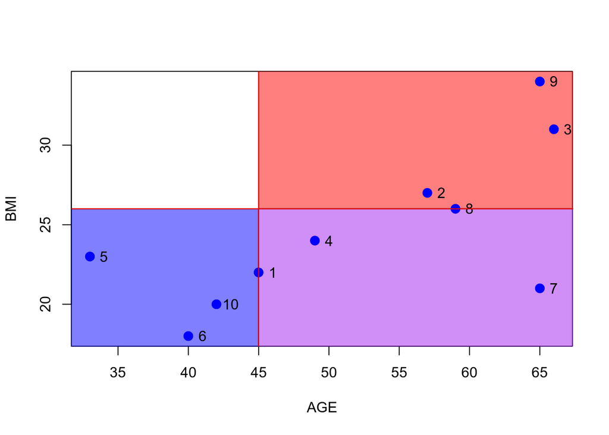

```r
plot(AGE, BMI,type="p",pch=20,cex=2,col="blue")
rect(xleft = 45, xright = 100, ybottom = 0, ytop = 26, col = scales::alpha("purple", 0.5))
rect(xleft = 45, xright = 100, ybottom = 26, ytop = 100, col = scales::alpha("red", 0.5))
rect(xleft = 0, xright = 45, ybottom = 0, ytop = 26, col = scales::alpha("blue", 0.5))
points(AGE, BMI,type="p",pch=20,cex=2,col="blue")
text(x = AGE + 1, y = BMI, labels = PID, col = "black")
abline(h = 26, v = 45, col = "RED")
```

"….Here the call to abline is for drawing vertical and horizontal lines so that we can count the numbers in each respective box. We now make the connection between set theory and operations clearer in the context of the data. In particular, we emphasize how set operations translate into logic operators that can then be used for data extraction and operations. Consider the following subsets of subjects:

A subjects with BMI< 26 and B subjects older than 45 (AGE> 45). Construct a logical indicator for which records fall into A…."

```r
#Group A, #represented by the points in the purple/blue regions
index_BMI_less_26 = BMI < 26
#Group B, #represented by the points in the purple/red regions
index_AGE_greater_45 = AGE > 45
```

“….Display the IDs for A and B. Here PID is the unique patient ID, though in many applications the PID can be more complex than just integer numbers….”

```r
PID[index_BMI_less_26]
```

```
## [1]  1  4  5  6  7 10
```

```r
PID[index_AGE_greater_45]
```

```
## [1] 2 3 4 7 8 9
```

```r
index_A_int_B_compl = !(index_BMI_less_26 & index_AGE_greater_45)
PID[index_A_int_B_compl]
```

```
## [1]  1  2  3  5  6  8  9 10
```

The translation of (A∩B<sup>c</sup> into R is !(index_BMI_less_26 & index_AGE_greater_45). Note that ! indicates is not, or complement, and & indicates and, or intersection. So, the resulting IDs are everybody, except the subject with IDs 4 and 7.

```r
index_A_int_B_compl = (index_BMI_less_26 & index_AGE_greater_45)
PID[index_A_int_B_compl]
```

```
## [1] 4 7
```

```r
index_A_int_B_compl = (index_BMI_less_26 & index_AGE_greater_45)
PID[index_A_int_B_compl]
```

```
## [1] 4 7
```

```r
index_A_int_B_compl = (index_BMI_less_26)
PID[index_A_int_B_compl]
```

```
## [1]  1  4  5  6  7 10
```

## 3.2 An intuitive introduction to the bootstrap

"….A major problem in practice is that, even if we run two identical experiments, data are never the same.

However, even though the two samples will be different, they will have some things in common. Those things are the target of estimation, the probability and time for conversion from being healthy to developing lung cancer, and the original target population…."

In practice we often have one study and we are interested in understanding what would happen if multiple studies were conducted. The reason for that is fundamental and it has to do with the generalizability of the experiment. Indeed, a study would collect data for a subsample of the population to make predictions about the rate and expected time of transition to lung cancer in the overall population. Bootstrap is a widely used statistical technique based on resampling the data. The bootstrap is designed to create many potential studies that share the same characteristics with the study that collected the data and may represent the vari- ability of running these experiments without actually running the experiments…."

“….The nonparametric bootstrap is the procedure of resampling with replacement from a dataset, where the number of observations in each resampled dataset is equal to the number of observations in the original dataset….”

So this is pretty much “take multiple random samples, the game” - Oh and here’s one way to do it:

```r
set.seed(4132697)
nboot=3 #number of boostrap samples
nsubj=nrow(data_bmi) #number of subjects
for (i in 1:nboot) #start bootstrapping
  {#begin the bootstrap for loop
    resampling = sample(nsubj, replace=TRUE) #sample with replacement
    bootstrapped_data = data_bmi[resampling,] #resample the data set
    print(bootstrapped_data) #print bootstrapped datasets
    cat(" \n \n") #add lines between datasets }#end the bootstrap for loop
  }#end the bootstrap for loop
```

```
##      PID BMI SEX AGE
## 6      6  18   0  40
## 8      8  26   1  59
## 2      2  27   0  57
## 10    10  20   0  42
## 3      3  31   1  66
## 10.1  10  20   0  42
## 9      9  34   1  65
## 3.1    3  31   1  66
## 1      1  22   1  45
## 4      4  24   1  49
##
##
##     PID BMI SEX AGE
## 6     6  18   0  40
## 6.1   6  18   0  40
## 10   10  20   0  42
## 8     8  26   1  59
## 7     7  21   0  65
## 8.1   8  26   1  59
## 1     1  22   1  45
## 1.1   1  22   1  45
## 6.2   6  18   0  40
## 5     5  23   0  33
##
##
##     PID BMI SEX AGE
## 7     7  21   0  65
## 9     9  34   1  65
## 3     3  31   1  66
## 7.1   7  21   0  65
## 3.1   3  31   1  66
## 9.1   9  34   1  65
## 8     8  26   1  59
## 9.2   9  34   1  65
## 2     2  27   0  57
## 8.1   8  26   1  59
##
##
```

"….A close look at these bootstrap samples will indicate what is meant by creating many potential studies that share the same characteristics. The subjects in every bootstrap sample are the same as those in the data, though some may not appear and others may appear multiple times. All information about the subject is preserved (information across columns is not scrambled), and the number of subjects in each bootstrap sample is the same as the number in the original dataset. This was done by using sampling with replacement of the subjects’ IDs using the same probability. Sampling with replacement can be conceptualized as follows:

1. consider a lottery machine that contains identical balls that have the name, or IDs, of n subjects;
2. sample one ball, record the ID and place the ball back into the lottery machine;
3. repeat the experiment n times

….Here we set the seed and the same exact boostrap samples are obtained every time this book is compiled. However, in practice if you run the code multiple times without the set.seed() option do not be surprised that every time the 3 bootstrap data sets change. This happens because of the random nature of the sampling mechanism. The total number of different nonparametric bootstrap datasets is 1010 , or 10 billion. If you want to always obtain the same dataset you can set the seed (this would need to be done before the sampling code) of the pseudo-random number (PRN) generator in R set.seed(4132697) The set.seed() function resets the PRN for the next simulation and does not have an effect on the previous simulation…."

**Example**:….Construct a 95% bootstrap confidence interval for the difference in the means of BMI of men and women, given this data set. The concept of a confidence interval has not been formally introduced. Instead, focus on finding the values of the difference in the mean that could be obtained if one collected data on five other men and five other women from the same target population.

Because we do not have the target population, resample with replacement from the five men and five women from the data we have….

```r
## Calculate the difference in average BMI between men and women in the original sample
file_name = "Example_Data/bmi_age.txt"
data_bmi = readr::read_table2(file = file_name)
attach(data_bmi)
men_bmi<-BMI[SEX==1] #vector of BMI values for men
women_bmi<-BMI[SEX==0] #vector of BMI values for women
n_women<-length(women_bmi) #number of women in the dataset
n_men<-length(men_bmi) #number of men in the dataset

## Display the difference in mean BMI between women and men
m_diff <- mean(men_bmi) - mean(women_bmi)
print(paste("the difference in mean BMI between women and men is ", m_diff))
```

```
## [1] "the difference in mean BMI between women and men is  5.6"
```

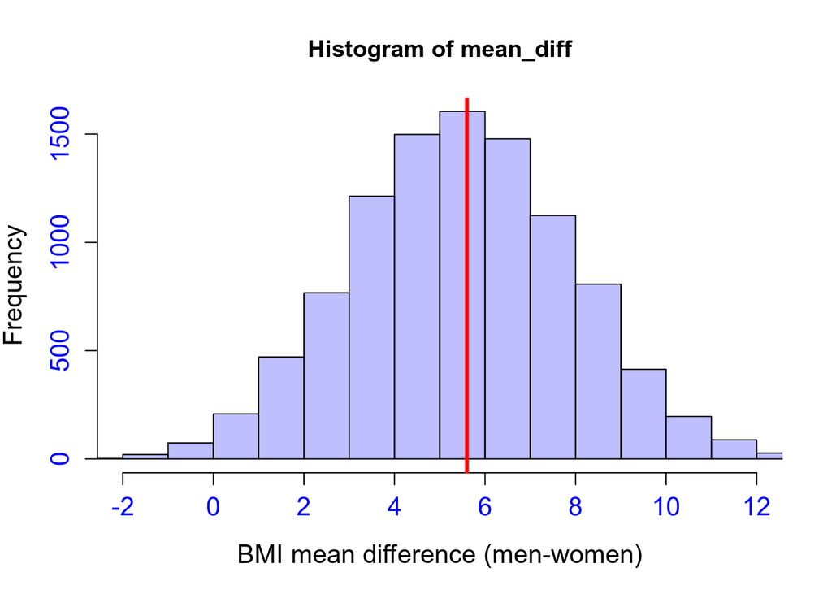

```r
## Conduct a bootstrap with 10000 resamples of the data. Create bootstrap samples of the data and for each sample calculate the mean difference between the BMI of men and women.
B_boot<-10000 #number of bootstrap samples
mean_diff=rep(NA,B_boot) #define the vector storing the differences in BMI
for (i in 1:B_boot)
  {#Begin bootstrap
    mm<-mean(men_bmi[sample(1:n_men,replace=TRUE)]) #calculate the mean for men
    mw<-mean(women_bmi[sample(1:n_women,replace=TRUE)]) #calculate the mean for women
    mean_diff[i]<-mm-mw #calculate and store the difference
  }#End bootstrap

## Visualize just how close these plausible values are to 5.6(m_diff) is to plot the histogram of the 10000 bootstrap samples of the mean difference:
hist(mean_diff,
     breaks=20,
     col=rgb(0,0,1,1/4),
     xlim=c(-2,12),
     xlab="BMI mean difference (men-women)",
     cex.lab=1.3,
     cex.axis=1.3,
     col.axis="blue")
abline(v = m_diff,col="red",lwd=3)
```

“….(m_diff) is the observed difference in the mean BMI between men and women. In biostatistics we call m_diff the estimator, which is a function of the data. m_diff, in itself cannot predict exactly what the mean difference in BMI will be in an identical study that collected data on five other men and five other women. It is natural to expect that the numbers observed in other studies should be close to m_diff, but we would like to know just how close. It is useful to observe….”

**Example:** (more details later once we learn about quantiles of the standard normal and empirical quantiles of a distribution).

```r
## Calculate the mean, standard deviation, and 95% confidence intervals (CIs) based on the Normal approximation or the bootstrap distribution
mBoot<-mean(mean_diff) #calculate the mean of the differences
sdBoot<-sd(mean_diff) #calculate the sd of the differences
CI1<-c(mBoot-1.96*sdBoot,mBoot+1.96*sdBoot) #normal approximation to the 95% CI
CI2<-quantile(mean_diff,probs=c(0.025,0.975)) #bootstrap 95% CI

## Display and compare the two 95% CIs (normal and bootstrap approximations)
```

```r
round(CI1, digits = 2) # normal approximation
```

```
## [1]  0.82 10.35
```

```r
CI2 # bootstrap approximation
```

```
##  2.5% 97.5%
##   0.8  10.4
```

“….The difference in length of the bootstrap and Normal approximation intervals as percent of the length of the Normal interval is 0.69 which is less than 1% difference….” What does this even mean? How is this number derived? This seems important.

The bootstrap results with:

- 95% Normal approximation confidence intervals (red)
- bootstrap quantile approximation (blue)

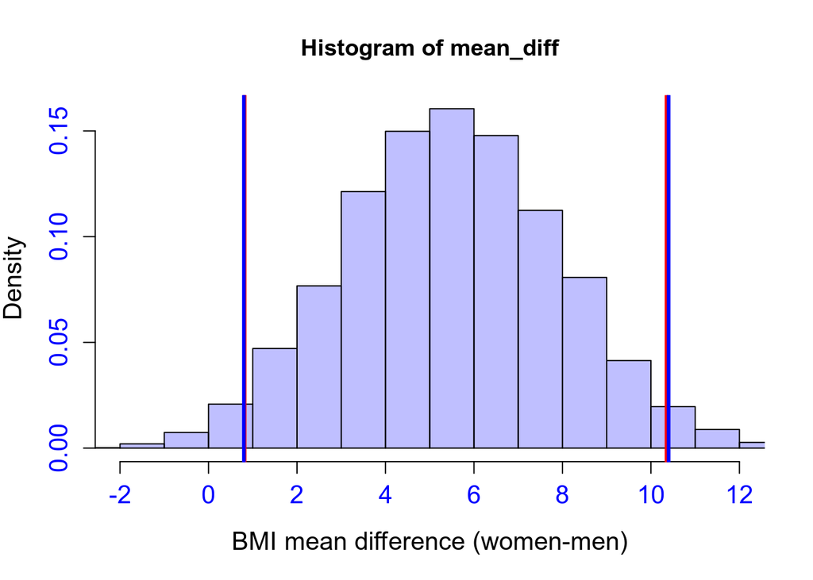

```r
hist(mean_diff, probability=TRUE, col=rgb(0,0,1,1/4), breaks=20,
     xlim=c(-2,12), xlab="BMI mean difference (women-men)",
     cex.lab=1.3, cex.axis=1.3, col.axis="blue")
abline(v = CI1,col="red",lwd=3)
abline(v = CI2,col="blue",lwd=3)
```

## 3.3 Probability

Bootstrap and confidence intervals have not been defined, though are very useful and intuitive. To better understand and anchor these concepts in a conceptual framework we need to introduce the notion of probability. Much of biostatistics uses this concept.

Probability has been found to be extraordinarily useful, even if true randomness is an elusive, undefined, quantity. While there is complete agreement on the mathematical rules probability must follow, disagreements about the interpretation of probability persist.

The frequentist interpretation of probability is *the proportion of times an event occurs in an infinite number of identical repetitions of an experiment.* The Bayesian interpretation of probability is *a subjective degree of belief with the understanding that for the same event, two separate people could have different probabilities.* While philosophical differences can be quite large, the practical differences to data analysis and inference are negligible.